# 数据产品招聘分析

## 总述

本节采集有效数据677条（按城市发布量>=10），主要分析数据产品岗位招聘和薪酬水平，我们将从如下方面分析：

- 城市分布：
  - 招聘主要分布在江浙和广东，其中，广州占24%，平均月薪16830元；上海占16%，平均月薪21248元；深圳占11%，平均月薪19102元；杭州占10%，平均月薪20242；江浙地区平均薪酬略高于广东地区。
- 行业分布：
  - 32%的招聘来自计算机软件，平均月薪19306元；互联网/电商占19%，平均月薪18214元，其余行业均在4%或以下。
- 公司规模：
  - 1000人以下招聘占64%，平均月薪17838元；1000-5000人占20%，平均月薪18202元；5000人以上占17%，平均月薪18762元。
- 公司类型：
  - 招聘市场主要以民营企业为主，占56%，平均月薪18750元；外企占10%，平均月薪16816元。
- 工作经验：
  - 75%的招聘要求5年以下，平均月薪15958元；5-10年占25%，平均月薪23785元；10以上占1%，平均月薪36986元。
- 学历要求：
  - 81%的招聘要求本科，平均月薪18549元；大专占12%，平均月薪14655元。
- 工作简述：
  - 数据分析、数据治理和数据安全，数据仓库和数据挖掘，建模和提供解决方案，熟练使用分析工具和程序语言如sql,python,bi,etl,hadoop,hive,webgl/golang/Spring等，熟悉互联网算法和迭代，熟悉业务需求和数据，设计产品，组织调研、监督合规、隐私保护等。

## 01.城市分布

[figure not shown]

roadmap

## 02.行业分布

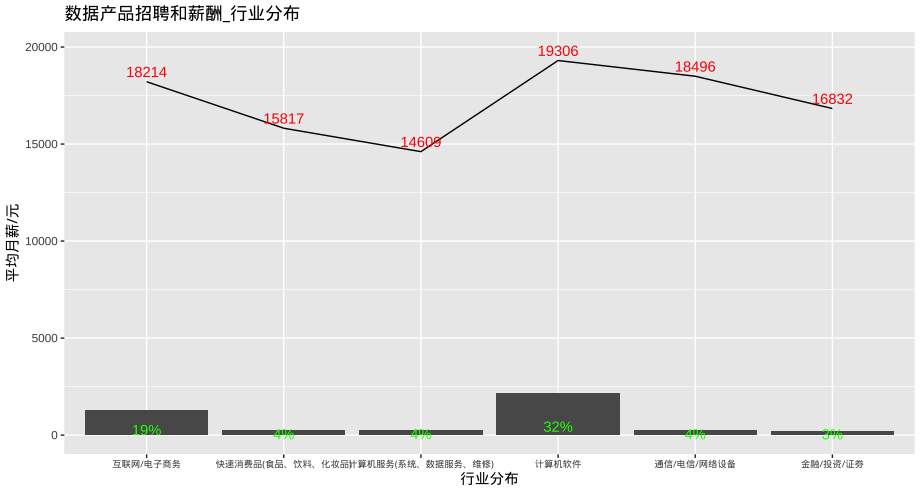

industries

## 03.公司规模

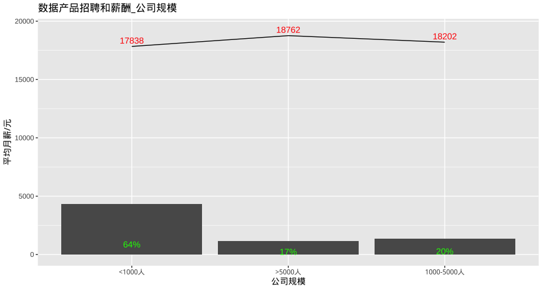

com_size

## 04.公司类型

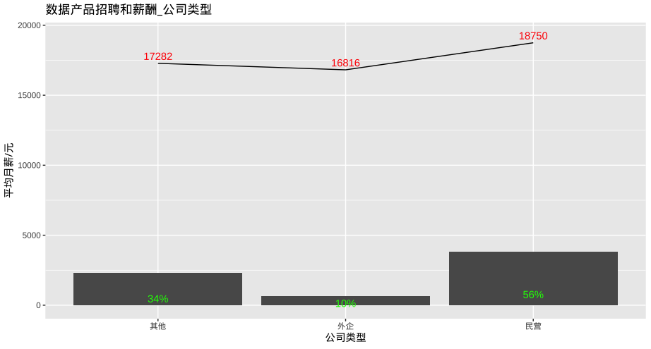

com_type

## 05.工作经验

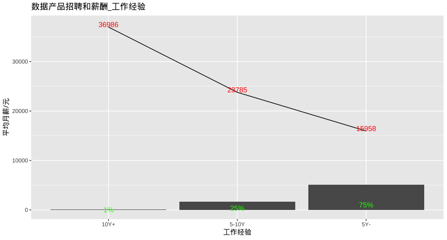

experience

## 06.学历要求

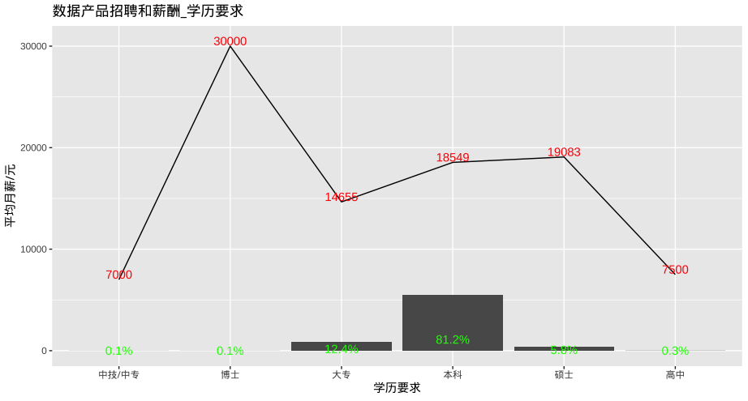

education

## 07.工作简述

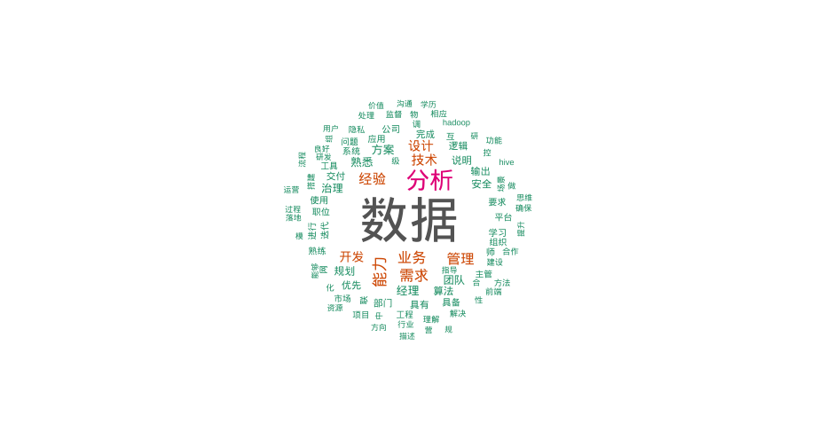

briefing